# Creating Curve Ensemble Summaries

## Importing data from BigQuery

```python
# get our query building function from the other file
from bin_builder import build_country_query
build_country_query
```

```
<function bin_builder.build_country_query(table, country_ids, run_ids, min_age, max_age, categories, grouped=True)>
```

```python
# construct query
# NOTE: since the rest of this file is about curve ensamble summaries, we import all runs of one country for a specific age
# group, but you can ask for as many countries and runs as you want
table = 'net-data-viz-handbook.sri_data.SIR_0_countries_incidence_daily'
country_ids = [215]
run_ids = list(range(1, 101))
min_age = 13
max_age = 23
categories = ['Infectious']

# Generate SQL query with grouped=True (default behavior)
query_grouped = build_country_query(table, country_ids, run_ids, min_age, max_age, categories, grouped=True)

# Generate SQL query with grouped=False (return individual bins)
query_separate = build_country_query(table, country_ids, run_ids, min_age, max_age, categories, grouped=False)

query_separate
```

```
'SELECT         date,         country_id,         run_id,         Infectious_13_17 AS infectious_13_17, Infectious_18_23 AS infectious_18_23     FROM `net-data-viz-handbook.sri_data.SIR_0_countries_incidence_daily`     WHERE country_id IN (215) AND run_id IN (1, 2, 3, 4, 5, 6, 7, 8, 9, 10, 11, 12, 1…
```

```python
# Initialize a GCS client
client = bigquery.Client(credentials=credentials, project=project)

# Run the query
query_job = client.query(query_grouped)

# Fetch the results into a DataFrame
results = query_job.to_dataframe()

# Display the first few rows
results.head()
```

|  | date | country_id | run_id | total_infectious |
| --- | --- | --- | --- | --- |
| 0 | 2009-02-17 | 215 | 49 | 0 |
| 1 | 2009-02-17 | 215 | 73 | 0 |
| 2 | 2009-02-17 | 215 | 23 | 0 |
| 3 | 2009-02-17 | 215 | 7 | 0 |
| 4 | 2009-02-17 | 215 | 48 | 0 |

## Process data

```python
# this doesn't have to happen in pandas; there are pros and cons of doing it in sql
""" This is how we create a graphing dataframe for plotly. use df.pivot, select your index, column, and values
    (which are columns of your original dataframe) """
df_pivot = results.reset_index().pivot(index='date', columns='run_id', values='total_infectious').fillna(0)

df_pivot.head()
```

| run_id date | 1 | 2 | 3 | 4 | 5 | 6 | 7 | 8 | 9 | 10 | ... | 91 | 92 | 93 | 94 | 95 | 96 | 97 | 98 | 99 | 100 |
| --- | --- | --- | --- | --- | --- | --- | --- | --- | --- | --- | --- | --- | --- | --- | --- | --- | --- | --- | --- | --- | --- |
| 2009-02-17 | 0 | 0 | 0 | 0 | 0 | 0 | 0 | 0 | 0 | 0 | ... | 0 | 0 | 0 | 0 | 0 | 0 | 0 | 0 | 0 | 0 |
| 2009-02-18 | 0 | 0 | 0 | 0 | 0 | 0 | 0 | 0 | 0 | 0 | ... | 0 | 0 | 0 | 0 | 0 | 0 | 0 | 0 | 0 | 0 |
| 2009-02-19 | 0 | 0 | 0 | 0 | 0 | 0 | 0 | 0 | 0 | 0 | ... | 0 | 0 | 0 | 0 | 0 | 0 | 0 | 0 | 0 | 0 |
| 2009-02-20 | 0 | 0 | 0 | 0 | 0 | 0 | 0 | 0 | 0 | 0 | ... | 0 | 0 | 0 | 0 | 0 | 0 | 0 | 0 | 0 | 0 |
| 2009-02-21 | 0 | 0 | 0 | 0 | 0 | 0 | 0 | 0 | 0 | 0 | ... | 0 | 0 | 0 | 0 | 0 | 0 | 0 | 0 | 0 | 0 |

5 rows × 100 columns

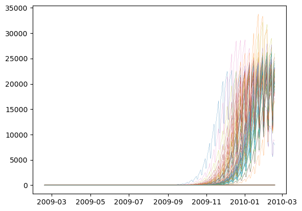

```python
plt.plot(df_pivot, lw=.2); # remove this semicolon at your own risk
```

## What is a function if not a bunch of Juyter cells glued together with duct tape and a prayer?

```python
def plot_curves(df_graph, df_info, labels, monocolor, save, method, downsample, freq, k, percentile, start):
    """
    Visualizes multiple curves with centrality and group coloring in a time-series plot.

    Parameters:
    - df_graph (pd.DataFrame): The data to plot, indexed by time.
    - df_info (pd.DataFrame): Data containing centrality and group information for each curve.
    - labels (array-like): Array of group labels for the curves.
    - monocolor (bool): If True, all curves are colored maroon; otherwise, colored by group.
    - save (bool): Whether to save the plot as an HTML file.
    - method (callable): Method used for curve distance calculation.
    - downsample (int): Frequency for downsampling the data.
    - freq (int): Frequency of curve comparison.
    - k (int): Number of clusters/groups for analysis.
    - percentile (float): Percentile for selecting central curves.
    - start (float): Start time for measuring processing duration.

    Returns:
    - fig (plotly.graph_objs.Figure): The generated plot.
    """

    # Prepare the figure
    print("Preparing figure for visualization...")
    colors = ['red', 'blue', 'green', 'cyan', 'yellow', 'gray']
    cmap = dict(zip(range(len(colors)), colors))
    fig = go.Figure()
    legend_groups = set()

    alphas = {i: df_info['group'].value_counts()[i] / df_info['group'].value_counts().sum() for i in np.unique(labels)}
    max_value = max(alphas.values())
    scaled_alphas = {i: value / max_value for i, value in alphas.items()}

    for curve in df_info.T[df_graph.columns].T.sort_values('centrality', ascending=True).index:
        c_gr = df_info['group'][curve]
        c_cen = df_info['centrality'][curve]
        c_alpha = scaled_alphas[c_gr]

        c_color = 'maroon' if monocolor else cmap[c_gr]

        show_legend = c_gr not in legend_groups
        if show_legend:
            legend_groups.add(c_gr)

        fig.add_trace(go.Scatter(
            name=f'Group {c_gr}' if show_legend else "",
            x=df_graph.index,
            y=df_graph[curve],
            marker=dict(color=color_to_rgba(c_color, c_cen, c_alpha)),
            line=dict(width=(c_cen / 2) ** 2),
            mode='lines',
            showlegend=show_legend,
            legendgroup=str(c_gr)
        ))

    # Title and axis labels
    print("Finalizing figure layout...")
    fig.update_layout(
        title=f'Curve Analysis: method={method.__name__}, downsample={downsample}, freq={freq}, k={k},<br>percentile={percentile}, \
time={round(time()-start, 4)}sec',
        xaxis_title='Date',
        yaxis_title='Incidence'
    )

    if save:
        filename = f'../images/ensamble_method-{method.__name__}_downsample-{downsample}_freq-{freq}_k-{k}_percentile-{percentile}.html'
        print("Saving figure as HTML file...")
        fig.write_html(filename)

    return fig
    print("Process complete.")
```

```python
def plot_cbp(df_graph, df_info, labels, monocolor, save, method, downsample, freq, k, percentile, start):
    """
    Visualizes a curve box plot (CBP) highlighting median, upper, and lower percentiles for each group.

    Parameters:
    - df_graph (pd.DataFrame): The data to plot, indexed by time.
    - df_info (pd.DataFrame): Data containing centrality and group information for each curve.
    - labels (array-like): Array of group labels for the curves.
    - monocolor (bool): If True, all groups are colored maroon; otherwise, colored by group.
    - save (bool): Whether to save the plot as an HTML file.
    - method (callable): Method used for curve distance calculation.
    - downsample (int): Frequency for downsampling the data.
    - freq (int): Frequency of curve comparison.
    - k (int): Number of clusters/groups for analysis.
    - percentile (float): Percentile for selecting central curves.
    - start (float): Start time for measuring processing duration.

    Returns:
    - fig (plotly.graph_objs.Figure): The generated plot.
    """

    # Prepare the figure
    print("Preparing figure for visualization...")
    colors = ['red', 'blue', 'green', 'cyan', 'yellow', 'gray']
    cmap = dict(zip(range(len(colors)), colors))
    fig = go.Figure()

    alphas = {i: df_info['group'].value_counts()[i] / df_info['group'].value_counts().sum() for i in np.unique(labels)}
    max_value = max(alphas.values())
    scaled_alphas = {i: value / max_value for i, value in alphas.items()}
#     print(scaled_alphas)


    for group in alphas.keys():
        dfg = df_graph.T[df_info['group'] == group].T
        median_idx = df_info[df_info['group']==group].sort_values('centrality', ascending=False).index[0]
        df_median = df_graph[median_idx]
        color = 'maroon' if monocolor else cmap[group]

        # Lower
        fig.add_trace(go.Scatter(
            name=f'Group {group} {percentile/2} percentile',
            x=dfg.index,
            y=dfg.T.min().values,
            marker=dict(color="#444"),
            line=dict(width=0),
            mode='lines',
            showlegend=False,
            legendgroup=str(group)  # Assign to legend group
        ))

        # Upper
        fig.add_trace(go.Scatter(
            name=f'Group {group} {100-percentile/2} percentile',
            x=dfg.index,
            y=dfg.T.max().values,
            mode='lines',
            marker=dict(color="#444"),
            line=dict(width=0),
            fillcolor=color_to_rgba(color, 1, scaled_alphas[group]/(max(alphas.keys())+1)),
            fill='tonexty',
            showlegend=False,
            legendgroup=str(group)  # Assign to legend group
        ))

        # Most Central Curve
        fig.add_trace(go.Scatter(
            name=f'Group {group}',
            x=df_median.index,
            y=df_median,
            marker=dict(color=color),
            line=dict(width=1),
            mode='lines',
            showlegend=True,  # Show legend for the central curve
            legendgroup=str(group)  # Assign to legend group
        ))

    fig.update_layout(
        title=f'Curve Box Plot: method={method.__name__}, downsample={downsample}, freq={freq}, k={k},<br>percentile={percentile}, \
time={round(time()-start, 4)}sec',
        xaxis_title='Date',
        yaxis_title='Incidence',
        showlegend=True
    )

    if save:
        filename = f'../images/curveboxplot_method-{method.__name__}_downsample-{downsample}_freq-{freq}_k-{k}_percentile-{percentile}.html'
        print("Saving figure as HTML file...")
        fig.write_html(filename)

    return fig
    print("Process complete.")
```

```python
def pipeline_curve_analysis(df, method, graph_method, downsample, freq, k, percentile, roll, monocolor=True, save=False):
    """
    A full pipeline for curve analysis, from calculating distances to visualizing the results.

    Parameters:
    - df (pd.DataFrame): Input data containing curves to analyze.
    - method (callable): Method used for calculating distance between curves.
    - graph_method (callable): Plotting function to visualize the curves.
    - downsample (int): Frequency for downsampling the data.
    - freq (int): Frequency of curve comparison.
    - k (int): Number of clusters/groups for analysis.
    - percentile (float): Percentile for selecting central curves.
    - roll (int): Number of days to roll average for graphing.
    - monocolor (bool, optional): If True, use a single color for all groups. Defaults to True.
    - save (bool, optional): Whether to save the plot as an HTML file. Defaults to False.

    Returns:
    - fig (plotly.graph_objs.Figure): The generated plot.
    """

    start = time()

    # Step 1: Get distance between curves
    print("Step 1: Calculating distance between curves...")
    fr = distance_between_curves(df, method=method, downsample=downsample, freq=freq)
    print("Distance calculation complete.")

    # Step 2: Generate groups
    print("Step 2: Generating groups...")
    labels = generate_groups(fr, k)
    print("Group generation complete.")

    # Step 3: Get centrality scores
    print("Step 3: Calculating centrality scores...")
    centrality = get_centrality(fr, labels)
    print("Centrality score calculation complete.")

    # Step 4: Get most central curves
    print("Step 4: Identifying most central curves...")
    most_central = get_most_central(labels, centrality, percentile)
    c = list()
    for cat in most_central.keys():
        c = c + most_central[cat]

    # Generate df_info for visualization
    print("Generating df_info for visualization...")
    df_info = pd.DataFrame(normalize_column(pd.Series(centrality)))
    df_info.columns = ['centrality']
    df_info['group'] = labels

    # Prepare rolling average data for graphing
    df_roll = df.rolling(roll).median().dropna()  # One week rolling average
    df_graph = df_roll[c]  # Using the most central curves only

    # Call the plot_curves function
    fig = graph_method(df_graph, df_info, labels, monocolor, save, method, downsample, freq, k, percentile, start)
    return fig
```

```python
# Example of how to call the function
fig = pipeline_curve_analysis(df_pivot, method=similaritymeasures.mse, graph_method=plot_cbp,
                              downsample=1, freq=1, k=3, percentile=50, roll=7,
                                monocolor=True, save=False)
```

```
Step 1: Calculating distance between curves...
```

```
Distance calculation complete.
Step 2: Generating groups...
Group generation complete.
Step 3: Calculating centrality scores...
Centrality score calculation complete.
Step 4: Identifying most central curves...
Generating df_info for visualization...
Preparing figure for visualization...
```

```python
fig.show()
```

[interactive chart not shown]

```python
fig.show()
```

[interactive chart not shown]

So far, we've...

- made data query-able from the cloud
- allowed for different grouping methods
- allowed for output customization
- and created multiple visualization methods for ensambles and curve box plots.

We still need to...

- allow returning of summary statistics
- deal with weekends (help!)
- write instructions for accessing data stored in cloud
- write documentation for using query and data visualization functions, which includes...
  - creating a default aestheic with Nicole's help
  - synthesizing the most relevant parts of `plotly` documentation

```python
fig.update_layout(showlegend=False,
                  title="This hurts my eyes.<br>\
<span style='font-size: 12px;'>I'd like a better solution than using a rolling average. I have some ideas, but...</span>").show()
```

[interactive chart not shown]

Plus...

- expand on query options with new query-building functions...
  - and improve QOL for current functions
- test the efficacy of the confidence intervals (*)
  - formal justification?
- more optimization (*)

...and do the dozen other aspects of this project that aren't just the spaghetti plots, but there's been progress there too.